# Exercise 12.9

Kári Hlynsson

April 2024

Consider the `USArrests` data. We will now perform hierarchical clustering on the states.

## Part (a)

Using hierarchical clustering with complete linkage and Euclidean distance, cluster the states.

```r
library(ISLR2)
data(USArrests)

hclust_unsc <- hclust(dist(USArrests), method = "complete")
```

Let’s take a look.

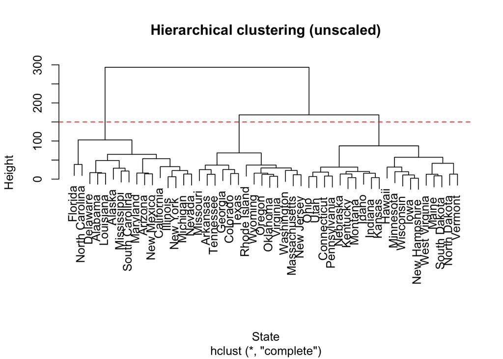

```r
plot(hclust_unsc, main = "Hierarchical clustering (unscaled)",
     xlab = "State")
abline(h = 150, lty = 2, col = "red")
```

## Part (b)

Cut the dendogram at a height that results in three distinct clusters. Which states belong to which clusters?

```r
clusters_unsc <- cutree(hclust_unsc, 3)

clusters_unsc
```

```
##        Alabama         Alaska        Arizona       Arkansas     California       Colorado    Connecticut       Delaware
##              1              1              1              2              1              2              3              1
##        Florida        Georgia         Hawaii          Idaho       Illinois        Indiana           Iowa         Kansas
##              1              2              3              3              1              3              3              3
##       Kentucky      Louisiana          Maine       Maryland  Massachusetts       Michigan      Minnesota    Mississippi
##              3              1              3              1              2              1              3              1
##       Missouri        Montana       Nebraska         Nevada  New Hampshire     New Jersey     New Mexico       New York
##              2              3              3              1              3              2              1              1
## North Carolina   North Dakota           Ohio       Oklahoma         Oregon   Pennsylvania   Rhode Island South Carolina
##              1              3              3              2              2              3              2              1
##   South Dakota      Tennessee          Texas           Utah        Vermont       Virginia     Washington  West Virginia
##              3              2              2              3              3              2              2              3
##      Wisconsin        Wyoming
##              3              2
```

```r
table(clusters_unsc)
```

```
## clusters_unsc
##  1  2  3
## 16 14 20
```

## Part (c)

Hierarchically cluster the states using complete linkage and Euclidean distance, *after scaling the variables to have standard deviation one*.

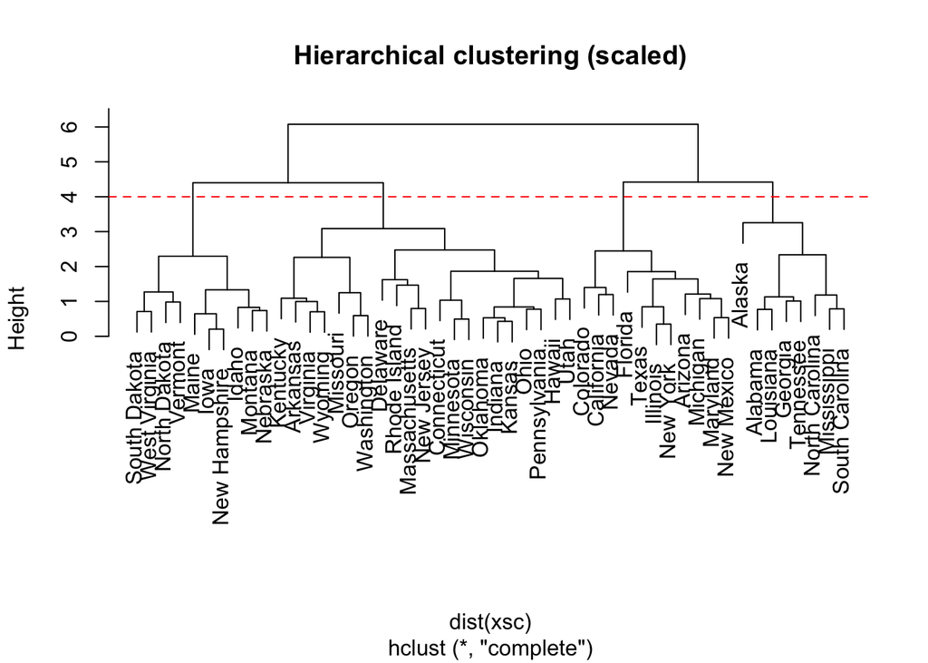

```r
xsc <- scale(USArrests)

hclust_sc <- hclust(dist(xsc), method = "complete")

plot(hclust_sc, main = "Hierarchical clustering (scaled)")
abline(h = 4, lty = 2, col = "red")
```

Let’s take a look at how the cluster groups look like:

```r
clusters_sc <- cutree(hclust_sc, 4)

clusters_sc
```

```
##        Alabama         Alaska        Arizona       Arkansas     California       Colorado    Connecticut       Delaware
##              1              1              2              3              2              2              3              3
##        Florida        Georgia         Hawaii          Idaho       Illinois        Indiana           Iowa         Kansas
##              2              1              3              4              2              3              4              3
##       Kentucky      Louisiana          Maine       Maryland  Massachusetts       Michigan      Minnesota    Mississippi
##              3              1              4              2              3              2              3              1
##       Missouri        Montana       Nebraska         Nevada  New Hampshire     New Jersey     New Mexico       New York
##              3              4              4              2              4              3              2              2
## North Carolina   North Dakota           Ohio       Oklahoma         Oregon   Pennsylvania   Rhode Island South Carolina
##              1              4              3              3              3              3              3              1
##   South Dakota      Tennessee          Texas           Utah        Vermont       Virginia     Washington  West Virginia
##              4              1              2              3              4              3              3              4
##      Wisconsin        Wyoming
##              3              3
```

```r
table(clusters_sc)
```

```
## clusters_sc
##  1  2  3  4
##  8 11 21 10
```

## Part (d)

What effect does scaling the variales have on the hierarchical clustering obtained? In your opinion, should the variables be scaled before the inter-observation dissimilarities are computed? Provide a justification for your answer.

We see that the dendrogram for the scaled variables is more balanced in the sense that we have four large subtrees, instead of the three produced by the unscaled response. It remains to be answered whether the data would suggest a clustering into 3 or 4 states – perhaps they are related by geography, political tendencies etc. I would likely prefer to scale the data, but I would need to look at how the groups change and whether there is any structure in either of the two clusterings produced.

It would be interesting to plot the clusters on a map of the USA to see whether we see any discernible patterns in the clustering.